# Week 1 - Skeleton and Basic Tests

A code skeleton for tree resolution algorithms which is robus and flexible was created and simple algorithms which are proven and have a theoretical throughput values in steady state were simulated ot check if the simulator works correctly.

## Test 1 - Static Tests

### 1.1 Simple Tree Resolution Algorithm

Collided Packets - 1000 No of test runs - 100 Branching Prob - 0.5 Theoretical Throughput - 0.346

Plot is the histogram of throughput over 100 runs

```
Mean Throughput is = 0.34655904135711596
```

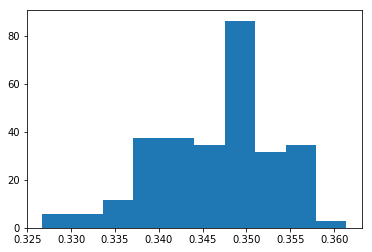

```python
import simstudy
simstudy.simulate_simple_tree_static_multpile_runs(modified=False, unisplit=False)
```

### 1.2 Modified Tree Resolution Algorithm

Here we skip a deterministic collision on the next slot if we have an IDLE slot after a COLLISION.

Collided Packets - 1000 No of test runs - 100 Branching Prob - 0.5 Theoretical Throughput - 0.375

```
Mean Throughput is = 0.37058107706941257
```

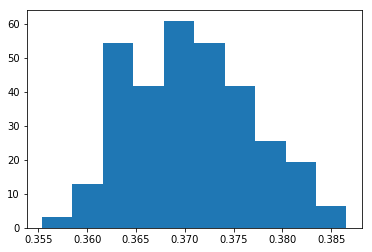

```python
import simstudy
simstudy.simulate_simple_tree_static_multpile_runs(modified=True, unisplit=False)
```

### 1.3 Optimum Tree Resolution

Here the first collision causes the tree to branch into K branches where K is the number of collided packets. Then it resumes a binary tree algorithm. Collided Packets - 1000 No of test runs - 100 Branching Prob - 0.5 Theoretical Throughput - 0.430

```
Mean Throughput is = 0.42696736780251654
```

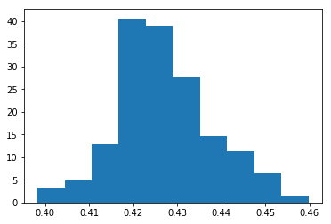

```python
import simstudy
simstudy.simulate_simple_tree_static_multpile_runs(modified=False, unisplit=True)
```

### Modified Optimum Tree

Here we combine the Modified Tree and Optimum tree Collided Packets - 1000 No of test runs - 100 Branching Prob - 0.5 Theoretical Throughput - 0.45??

```
Mean Throughput is = 0.45137387137603435
```

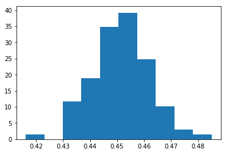

```python
import simstudy
simstudy.simulate_simple_tree_static_multpile_runs(modified=True, unisplit=True)
```

## Test 2 - Dynamic Tests with Poisson Arrivals

### 2.1 Simple Tree Resolution Algorithm

```python
import simstudy
import simulation
sim = simulation.Simulation()
simstudy.simulate_simple_tree_dynamic(sim, modified=False, unisplit=False)
```

```
Throughput = 0.3384338433843384
Mean Packet Delay = 48.124704491725765
Mean number of retx = 3.891548463356974
```

```python
import simstudy
import simulation
sim = simulation.Simulation()
simstudy.simulate_simple_tree_dynamic(sim, modified=True, unisplit=False)
```

```
Throughput = 0.33933393339333934
Mean Packet Delay = 14.966990863542588
Mean number of retx = 3.0506926024167402
```

### Issues -

How to go about to show that the Dynamic Simulations are as per the expected theoretical values. Too much "randomeness".